# Correct for differences in cell cycle (GCBC)

Ramon Massoni-Badosa

2023-06-24

# 1 Introduction

In this notebook, we will answer the following comment from reviewer 1:

*“The cell cycle seems to have a very important effect on the resulting embedding of sc/snRNA-seq data. Have the authors considered accounting for the cell cycle (e.g. regressing out or removing cell cycle-associated genes) before doing dimensionality reduction and UMAP embedding? Having such a big cluster of cycling cells (which likely correspond to several distinct cell types that are pulled together in the embedding just for being in active proliferation) can mask relevant biology.”*.

# 2 Pre-processing

## 2.1 Load packages

```r
library(Seurat)
library(harmony)
library(scater)
library(SingleCellExperiment)
library(tidyverse)
library(here)
library(glue)
library(ggrastr)
library(lisi)
```

## 2.2 Define parameters

```r
# Source paths and functions
gcbc_levels_old <- c("DZ early Sphase", "DZ late Sphase", "DZ early G2Mphase",
                 "DZ late G2Mphase", "DZ cell cycle exit", "DZ non proliferative",
                 "DZ_LZ transition", "LZ", "LZ_DZ reentry commitment", "LZ proliferative",
                 "LZ_DZ transition", "Precursor MBCs", "Reactivated proliferative MBCs",
                 "prePC")
gcbc_levels_new <- c("DZ early Sphase", "DZ late Sphase", "DZ early G2Mphase",
                     "DZ late G2Mphase", "DZ cell cycle exit", "DZ non proliferative",
                     "DZ-LZ transition", "LZ", "LZ-DZ reentry commitment", "LZ proliferative",
                     "LZ-DZ transition", "Precursor MBCs", "Reactivated proliferative MBCs",
                     "PC Commited Light Zone GCBC")
colors_gcbc <- c("#056dbd", "#004f89", "#6c629f", "#857daf", "#2e2e4a", "#326200",
                 "#d3ee9d", "#fdf498", "#deefef", "#9bd4fc", "#4eaffc", "#c9b86d",
                 "#574c2e", "#fbcfc2")
names(colors_gcbc) <- gcbc_levels_new
cols_cc <- c("G2M" = "#e69f00", "S" = "#56b4e9", "G1" = "#009e73")
theme_blank <- function() {
  theme(
    plot.title = element_blank(),
    axis.line = element_blank(),
    axis.text = element_blank(),
    axis.title = element_blank(),
    axis.ticks = element_blank()
  )
}
```

## 2.3 Load data

```r
seurat <- readRDS(here("scRNA-seq/results/R_objects/final_clusters/20230124/20230124_GCBC_seurat_obj.rds"))
seurat <- seurat[, seurat$assay == "3P"]
```

# 3 Plot GCBC without cell cycle correction

## 3.1 UMAPS

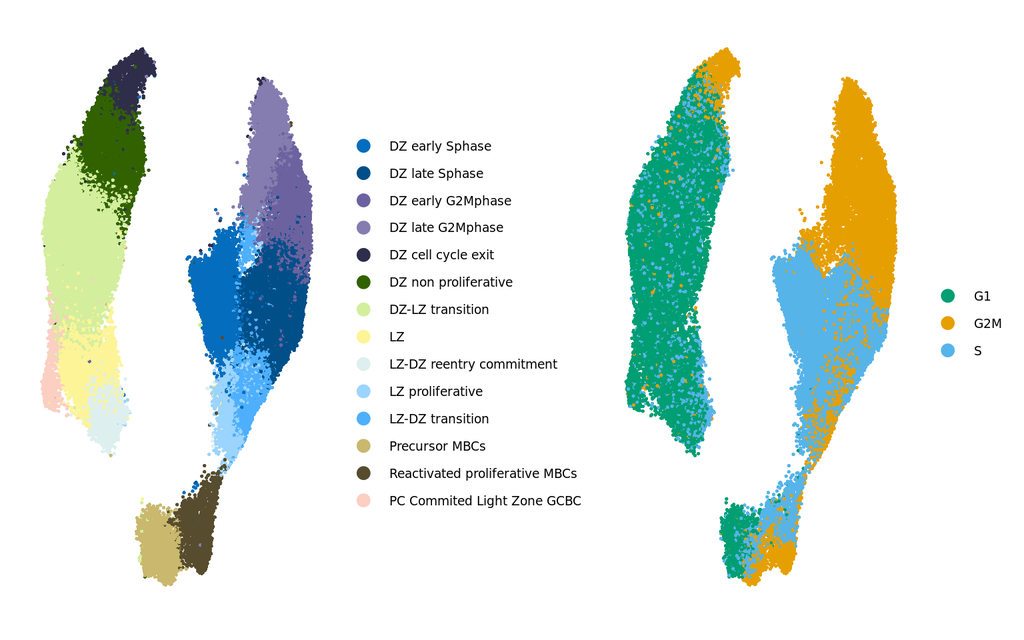

```r
seurat$annotation_20230124 <- factor(
  seurat$names_level_5_clusters_eta,
  levels = gcbc_levels_old
)
levels(seurat$annotation_20230124) <- gcbc_levels_new
umap_annot_original <- DimPlot(
  seurat,
  group.by = "annotation_20230124",
  pt.size = 0.1,
  cols = colors_gcbc,
  shuffle = TRUE
) +
  theme_blank() +
  theme(legend.text = element_text(size = 7))
umap_annot_original <- rasterise(umap_annot_original, dpi = 600)
umap_cc_original <- DimPlot(
  seurat,
  group.by = "Phase",
  pt.size = 0.1,
  cols = cols_cc,
  shuffle = TRUE
) +
  theme_blank() +
  theme(legend.text = element_text(size = 7))
umap_cc_original <- rasterise(umap_cc_original, dpi = 600)
umap_annot_original | umap_cc_original
```

## 3.2 LISI scores

We use the [Local Inverse Simpson Index (LISI)](https://github.com/immunogenomics/LISI) to quantify the batch diversity at the neigborhood of each cell:

```r
harmony_original <- Embeddings(seurat, "harmony")[, 1:30]
metadata_df <- seurat@meta.data[, c("annotation_20230124", "Phase")]
lisi_original <- compute_lisi(
  harmony_original,
  metadata_df,
  c("annotation_20230124", "Phase")
)
lisi_original$group <- "No CC correction"

# Save
dir.create(here("scRNA-seq/6-revision/tmp"))
saveRDS(umap_annot_original, here("scRNA-seq/6-revision/tmp/umap_annot_original.rds"))
saveRDS(umap_cc_original, here("scRNA-seq/6-revision/tmp/umap_cc_original.rds"))
saveRDS(lisi_original, here("scRNA-seq/6-revision/tmp/lisi_original.rds"))
```

# 4 Remove genes correlated with cell cycle

The first strategy to remove the effect of cell cycle from dataset is to remove the genes which show a high correlation with cell cycle. We follow the steps explained in [this vignette](http://bioconductor.org/books/3.17/OSCA.advanced/cell-cycle-assignment.html#removing-cell-cycle-related-genes):

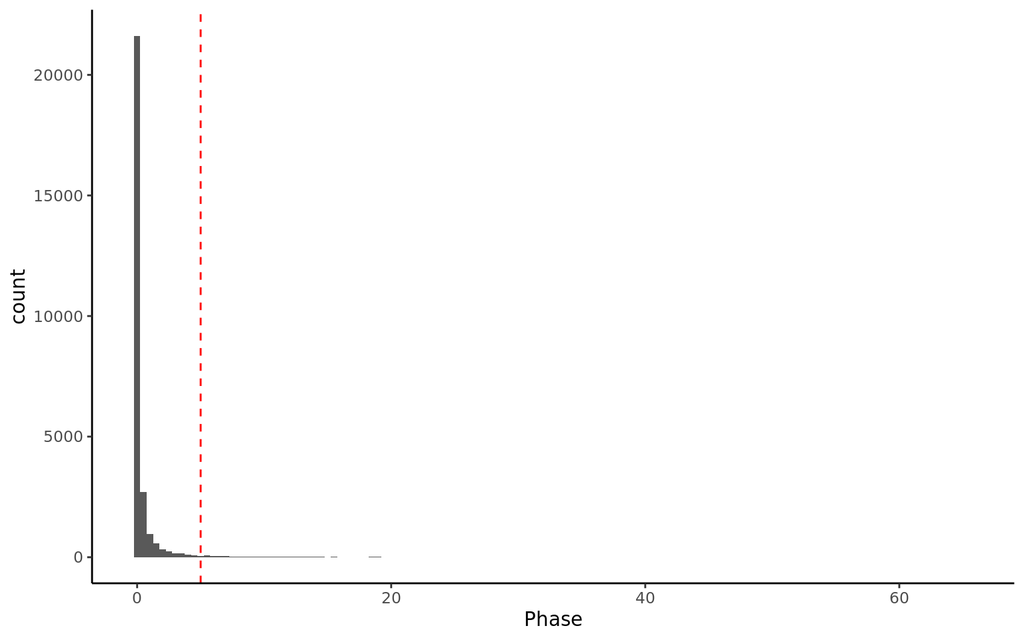

```r
sce <- as.SingleCellExperiment(seurat)
var_explained <- getVarianceExplained(sce, "Phase")
var_explained_df <- as.data.frame(var_explained)
var_explained_df <- var_explained_df[!(is.na(var_explained_df$Phase)), , drop = FALSE]
var_explained_df %>%
  ggplot(aes(Phase)) +
  geom_histogram(binwidth = 0.5) +
  geom_vline(xintercept = 5, linetype = "dashed", color = "red") +
  theme_classic()
```

```r
table(var_explained_df$Phase >= 5)
```

```
##
## FALSE  TRUE
## 26981   799
```

```r
cell_cycle_genes <- rownames(var_explained_df)[var_explained_df$Phase >= 5]
seurat <- FindVariableFeatures(seurat, nfeatures = 2500)
var_features <- VariableFeatures(seurat)[!(VariableFeatures(seurat) %in% cell_cycle_genes)]
seurat <- ScaleData(seurat, features = var_features)
seurat <- RunPCA(seurat, features = var_features)
seurat <- RunHarmony(
  seurat,
  group.by.vars = "gem_id",
  dims.use = 1:30,
  reduction = "pca",
  max.iter.harmony = 20
)
seurat <- RunUMAP(seurat, dims = 1:30, reduction = "harmony")
```

## 4.1 UMAPS

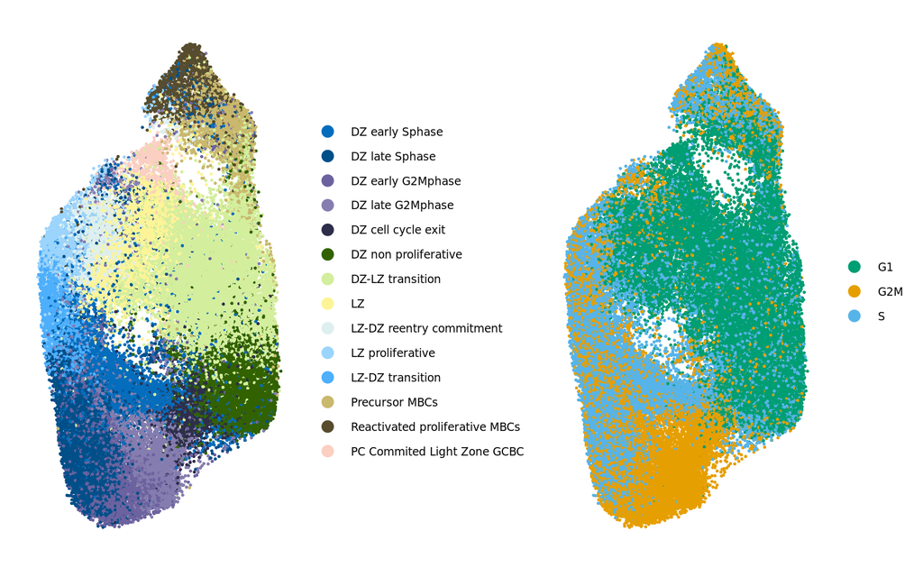

```r
umap_annot_no_cc_genes <- DimPlot(
  seurat,
  group.by = "annotation_20230124",
  pt.size = 0.1,
  cols = colors_gcbc,
  shuffle = TRUE
) +
  theme_blank() +
  theme(legend.text = element_text(size = 7))
umap_annot_no_cc_genes <- rasterize(umap_annot_no_cc_genes, dpi = 600)
umap_cc_no_cc_genes <- DimPlot(
  seurat,
  group.by = "Phase",
  pt.size = 0.1,
  cols = cols_cc,
  shuffle = TRUE
) +
  theme_blank() +
  theme(legend.text = element_text(size = 7))
umap_cc_no_cc_genes <- rasterize(umap_cc_no_cc_genes, dpi = 600)
umap_annot_no_cc_genes | umap_cc_no_cc_genes
```

## 4.2 LISI scores

```r
harmony_no_cc_genes <- Embeddings(seurat, "harmony")[, 1:30]
lisi_no_cc_genes <- compute_lisi(
  harmony_no_cc_genes,
  metadata_df,
  c("annotation_20230124", "Phase")
)
lisi_no_cc_genes$group <- "Removed CC genes"

# Save
saveRDS(umap_annot_no_cc_genes, here("scRNA-seq/6-revision/tmp/umap_annot_no_cc_genes.rds"))
saveRDS(umap_cc_no_cc_genes, here("scRNA-seq/6-revision/tmp/umap_cc_no_cc_genes.rds"))
saveRDS(lisi_no_cc_genes, here("scRNA-seq/6-revision/tmp/lisi_no_cc_genes.rds"))
```

# 5 Dimensionality reduction after cell cycle regression

In a previous script we followed the [cell cycle regression vignette from Seurat](https://satijalab.org/seurat/articles/cell_cycle_vignette.html). Here, we proceed to reduce the dimensionality and compute UMAP and LISI scores.

```r
rm(seurat)
gc()
```

```
##             used   (Mb) gc trigger  (Mb)   max used    (Mb)
## Ncells   8405760  449.0   14211185   759   14211185   759.0
## Vcells 795247834 6067.3 1935920402 14770 1908806617 14563.1
```

```r
seurat_regressed <- readRDS(here("scRNA-seq/results/R_objects/revision/seurat_gcbc_cell_cycle_regressed.rds"))
seurat_regressed <- RunPCA(seurat_regressed, features = VariableFeatures(seurat_regressed))
seurat_regressed <- RunHarmony(
  seurat_regressed,
  group.by.vars = "gem_id",
  dims.use = 1:30,
  reduction = "pca",
  max.iter.harmony = 20
)
seurat_regressed <- RunUMAP(seurat_regressed, dims = 1:30, reduction = "harmony")
```

## 5.1 UMAPS

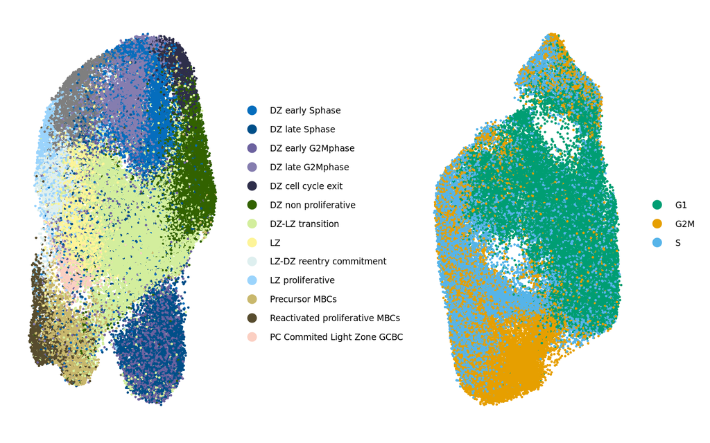

```r
umap_annot_regressed <- DimPlot(
  seurat_regressed,
  group.by = "annotation_20230124",
  pt.size = 0.1,
  cols = colors_gcbc,
  shuffle = TRUE
) +
  theme_blank() +
  theme(legend.text = element_text(size = 7))
umap_annot_regressed <- rasterize(umap_annot_regressed, dpi = 600)
umap_cc_regressed <- DimPlot(
  seurat_regressed,
  group.by = "Phase",
  pt.size = 0.1,
  cols = cols_cc
) +
  theme_blank() +
  theme(legend.text = element_text(size = 7))
umap_cc_regressed <- rasterize(umap_cc_regressed, dpi = 600)
umap_annot_regressed | umap_cc_no_cc_genes
```

## 5.2 LISI scores

```r
harmony_regressed <- Embeddings(seurat_regressed, "harmony")[, 1:30]
lisi_regressed <- compute_lisi(
  harmony_regressed,
  metadata_df,
  c("annotation_20230124", "Phase")
)
lisi_regressed$group <- "CC regressed out"

# Save
saveRDS(umap_annot_regressed, here("scRNA-seq/6-revision/tmp/umap_annot_regressed.rds"))
saveRDS(umap_cc_regressed, here("scRNA-seq/6-revision/tmp/umap_cc_regressed.rds"))
saveRDS(lisi_regressed, here("scRNA-seq/6-revision/tmp/lisi_regressed.rds"))
```